# Bonanza juvenile hare counts and sizes: exploratory report

Kirsten Hodgson

11/20/2020

### 1. Introduction

This report explores differences in the count and size of juvenile snowshoe hares observed at the Bonanza Creek Long Term Ecological Research site between 1998 and 2012. The data was collected for capture-recapture studies and includes observations of weight, age, sex, and hind foot length which are relevant to this exploration (Kielland et. al 2017). First, I explore the annual count of juvenile hares trapped at all grid sites (Bonanza Black Spruce, Bonanza Mature, and Bonanza Riparian). Then, I explore differences in weight of juvenile hares by sex and grid site, and conduct a means comparison of weight between male and female hares across all grid sites. Lastly, I explore the relationship between hind foot length and weight in juvenile snowshoe hares.

### 2. Data and Analyses

Knut Kielland et al. collected, compiled, and made available the data from their study of physical parameters of snowshoe hares at the Bonanza Creek Long Term Ecological Research site, near Fairbanks, Alaska. The data include measurements of age, sex, and physical parameters such as weight and hind foot length for almost 3200 observed hares from 1998 through 2012. I conducted all data analyses in R version 4.0.2 using RStudio version 1.3.1093. Starting with an exploration of the number of juvenile hares trapped annually, I then explored the relationship between sex and weight via a two-sample t-test. Effect size was calculated using Cohen’s *d*. Lastly, a linear regression analysis using simple linear regression was used to explore the relationship between juvenile hare weight and hind foot length. The significance level, $\alpha$, is 0.05 throughout this exploration. Some portions of code are adapted from Allison’s example report, particularly in the linear regression section.

### 3. Exploratory Findings

#### A. Annual juvenile hare trap counts

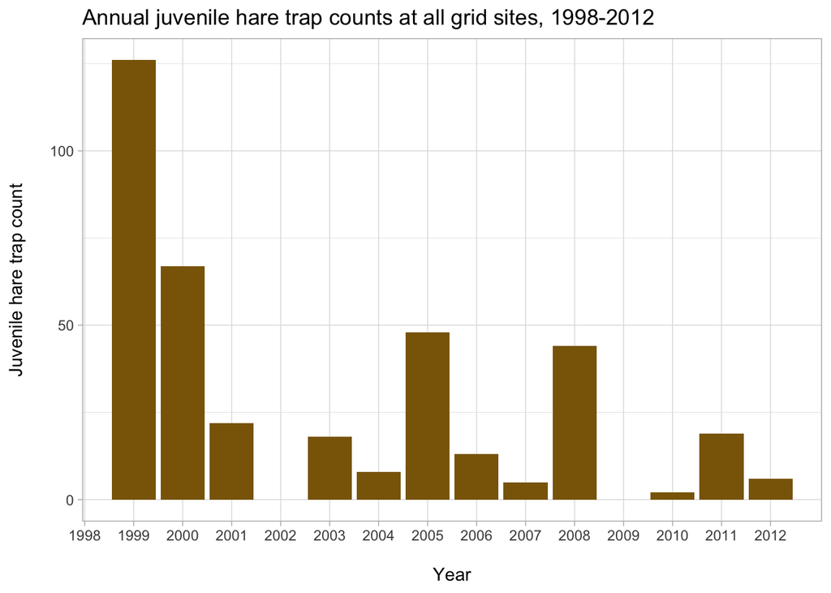

**Figure 1.** Annual hare trap counts for juvenile snowshoe hares at all grid sites (Bonanza Black Spruce, Bonanza Mature, Bonanza Riparian), 1998-2012. Bars represent the number of juvenile hares counted per year across all sites. Trap counts tended to decrease over time with occasional spike years (1999, 2000, 2005, 2008). In three years (1998, 2002, 2009) no juvenile hares were observed. Data: Kielland et al. (2017).

#### B. Visualizing juvenile hare weights

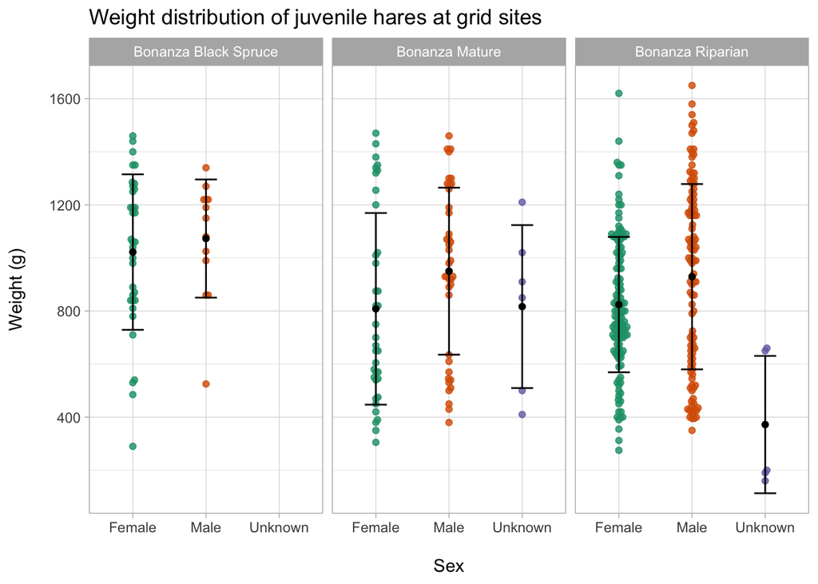

**Figure 2.** Weight (g) of juvenile snowshoe hares by sex (female, male, unknown) at each trapping grid site. Green (female), orange (male), and violet (unknown) points indicate individual observations of weight (g) of a trapped juvenile hare. Black points indicate group mean, and black error bars indicate distance of one standard deviation from the group mean. Data: Kielland et al. (2017).

From exploration of the graphs, mean weights of male juvenile hares appear higher than female and unknown mean weights. At the Bonanza Black Spruce site, there were no juvenile hares of unknown sex, which explains the absence of any points in that column. At the other two sites, the sample size for unknown hares is much smaller than that of male and female sites. While the male mean weights are higher than either the female or unknown, in all groups the male and female mean weights are within one standard deviation of each other, and more testing is needed to compare the groups effectively.

#### C. Comparing weights of male and female juvenile hares

**Table 1.** Summary statistics (mean, standard deviation, and sample size) for weight comparison of juvenile female and male snowshoe hares in Bonanza Creek Experimental Forest, 1998-2012. Data: Kielland et al. (2017).

| Sex | Mean Weight (g) | Standard Deviation (g) | Sample Size |
| --- | --- | --- | --- |
| Female | 855.3909 | 292.2526 | 200 |
| Male | 945.8589 | 333.2151 | 163 |

Juvenile male snowshoe hares have a higher weight than juvenile female snowshoe hares, on average. Male and female weights are 945.86 $\pm$ 333.22 and 855.39 $\pm$ 292.25 g, respectively (mean $\pm$ 1 standard deviation). The absolute difference in means is 90.47, and the percent difference is 10.05. This difference in means is significant (Welch’s two-sample t-test: t(325.02) = 2.71, p < 0.01), but the effect size is small (Cohen’s *d* = 0.29). This means that the probability that sample means this different could have been taken from populations with the same mean is 1%, but while there is a real difference in means, detecting it would require detailed study. The large sample size of both male and female juvenile hares (163 and 200, respectively) likely accounts for detecting it here.

#### D. Relationship between juvenile weight and hind foot length

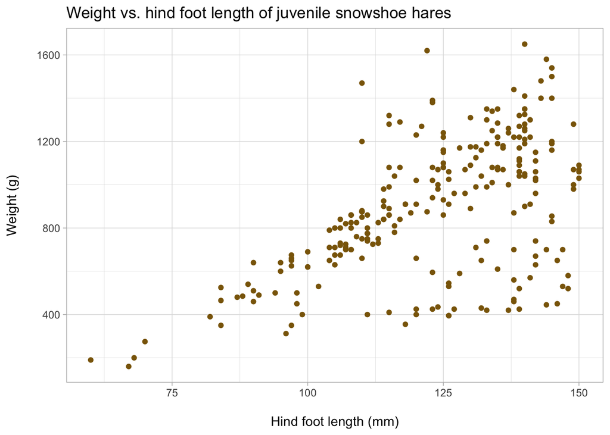

**Figure 3.** The relationship between weight (g) and hind foot length (mm) in juvenile snowshoe hares. Brown points indicate individual observations of male or female juvenile hares (n = 363) across all three Bonanza Creek grid sites (Bonanza Black Spruce, Bonanza Mature, and Bonanza Riparian) for the length of the study, 1998-2012. Data: Kielland et al. (2017).

Hind foot length predicts weight (p < 0.001, R<sup>2</sup> = 0.3) with an average slope of $\beta$ = 9.52 g mm<sup>-1</sup>. Thus, according to the model, for every mm of increased hind foot length, hare weight increases *on average* 9.52 g. However, the R<sup>2</sup> value of 0.3 indicates that only 30% of the variance in weight is predicted by hind foot length. Weight and hind foot length are moderately positively correlated (Pearson’s *r* = 0.55, p < 0.001).

### Summary

In my exploration of the juvenile hare trap data, I found that:

- Annual trap rates of juvenile hares has decreased overall since the beginning of the study, with a few occasional spike years. However, this trap rate is influenced by effort, which is not accounted for in my exploration.
- Male juvenile snowshoe hares have a higher mean body weight than female juvenile snowshoe hares. The means difference is significant, but the effect size is small. Although the t-test and effect size were taken for the population as a whole, this trend is suggested across each of the three grid sites in Figure 2.
- By simple linear regression, hind foot length and weight are moderately positively correlated in juvenile snowshoe hares of both male and female sex. However, only 30% of the variance in weight is explained by hind foot length, indicating that other variables must be considered. Additionally, I have some concerns about homoscedasticity, and other means of regression should be considered.

Next steps:

- Consider a multiple regression, potentially of a higher order, to better understand the relationship between sex, hind foot length, and weight.
- Analysis of weight means difference by sex at each of the three grid sites to determine if the relationship holds at a smaller scale.

### Citations

Data citation: Kielland, K., F.S. Chapin, R.W. Ruess, and Bonanza Creek LTER. 2017. Snowshoe hare physical data in Bonanza Creek Experimental Forest: 1999-Present ver 22. Environmental Data Initiative. https://doi.org/10.6073/pasta/03dce4856d79b91557d8e6ce2cbcdc14